# IODS Course Project

Mikko Salonen

24 February 2017

# Abstract

We analyse financial data to predict future stock prices. Data includes typical stock metrics that are used when deciding upon investing on a stock. We find that if price of the stock has gone down during the previous year it is likely the price will gain in the future. Likewise, some sectors with high net profit margin tend to rise in price in the future.

# Preliminaries and Data

We analyse financial data from the SP500 index. We have data on historical prices and historical results of the companies (http://data.okfn.org/data/core/s-and-p-500-companies). We try to analyse which components predict future stock price. Update prices are fetched using quantmod package. The data wrangling file can be found at https://github.com/maasal/IODS-final/blob/master/data/datacreate.R.

We have data on comparable stock variables, namely: price per earnings (PE), price per sales (PS), price per book value (PB), dividents (Div). We also have data on sector of the firm (Sector), recent price change (diff, the higher more the stock has fallen during last 52 week period), and our dependent variable stock price change later (P). These variables are commonly used when making an investment decision. Our hypothesis is that all relevant information is embedded in the stock price and none of the variables have an effect in predicting the future stock price.

From the correlation matrix we can see that there is only slight correlation between the variables. The biggest is correlation between stocks that had fallen and future price. However, price per sales seems to be negatively correlated with both of these variables.

```r
setwd("~/Documents/IODS/git/IODS-final/")
financial <- read.csv("data/financial.csv",row.names = "X")

library(GGally)
library(corrplot)
library(dplyr)


summary(financial)
```

```
##                     Sector        Div               PE
##  Financials            :82   Min.   : 0.000   Min.   :  2.15
##  Consumer Discretionary:64   1st Qu.: 1.520   1st Qu.: 14.76
##  Industrials           :59   Median : 2.370   Median : 21.40
##  Information Technology:42   Mean   : 2.352   Mean   : 29.26
##  Health Care           :36   3rd Qu.: 3.070   3rd Qu.: 29.34
##  Consumer Staples      :30   Max.   :10.620   Max.   :713.08
##  (Other)               :64
##        PS               PB               diff             P
##  Min.   : 0.120   Min.   :  0.300   Min.   :100.0   Min.   :-77.804
##  1st Qu.: 1.220   1st Qu.:  1.920   1st Qu.:101.4   1st Qu.: -6.326
##  Median : 2.210   Median :  2.990   Median :106.5   Median :  3.452
##  Mean   : 2.877   Mean   :  7.949   Mean   :115.7   Mean   :  8.008
##  3rd Qu.: 3.380   3rd Qu.:  5.420   3rd Qu.:122.1   3rd Qu.: 18.751
##  Max.   :17.630   Max.   :442.970   Max.   :282.9   Max.   :105.565
##
```

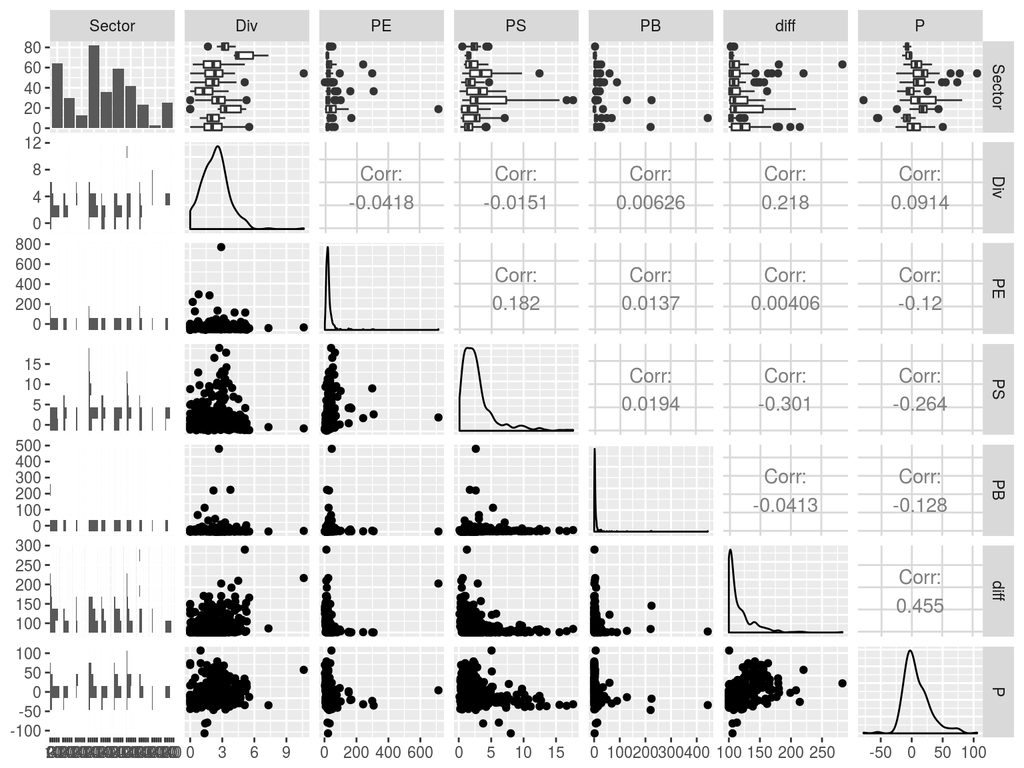

```r
# visualize the 'human_' variables
ggpairs(financial, lower = list(combo = wrap("facethist", bins = 7)))
```

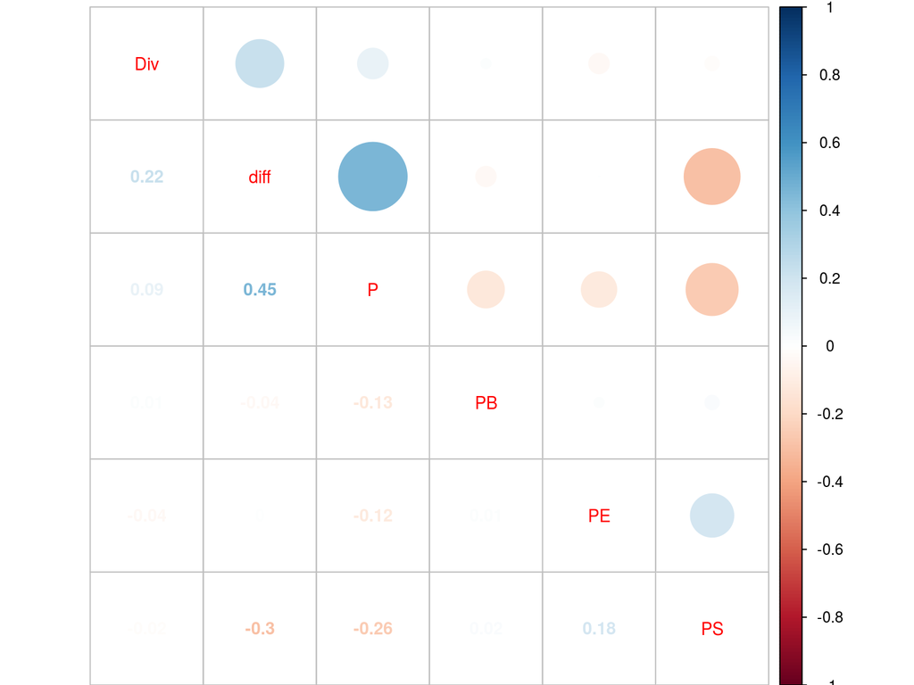

```r
# compute the correlation matrix and visualize it with corrplot
cor(financial[,-1]) %>% round(digits=2) %>% corrplot.mixed(tl.cex = 0.9,number.cex=0.9,order="hclust",addrect=2)
```

Let’s take a closer look at the PS variable and how the density changes between sectors. From the plot below we can see that financial, information technology and to some degree health care sectors have right tailed distributions and there are more stocks in these sectors that have fairly high price but their turnover is not as large compared to other companies. This phenomenom usually coencides with high net margins, and this is a fair assumption for technology, finance, and health care firms.

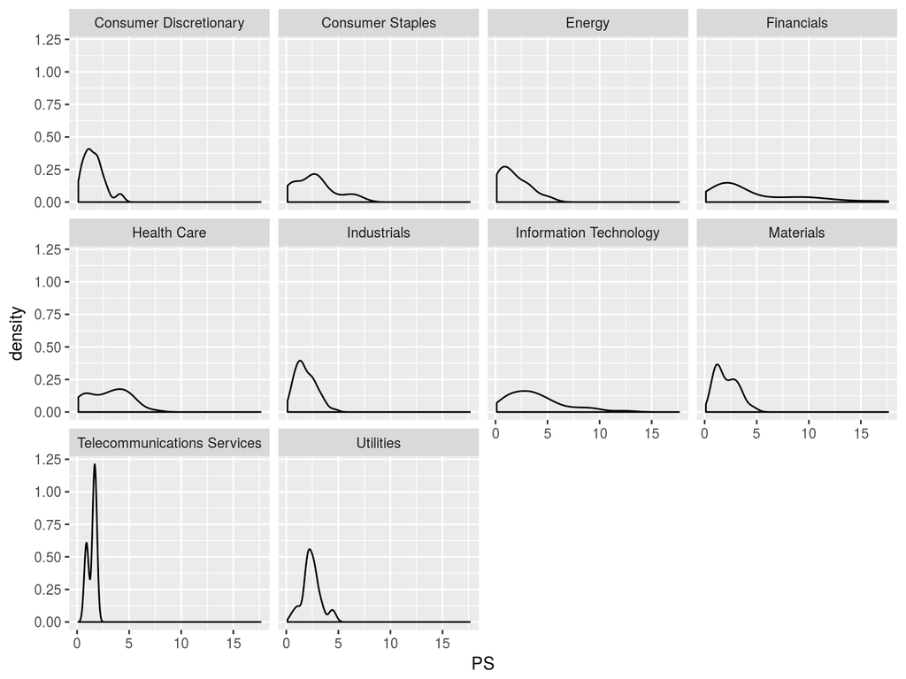

```r
library(ggplot2)
g <- ggplot(financial, aes(PS))
g + geom_density() + facet_wrap( ~Sector) +theme_set(theme_gray(base_size = 9))
```

# Model

We model the predictability of future prices (P) based on other variables. Our model is:

> P ~ PB + PE + PS + diff + Div + Sector

> P ~ PB + PS + diff + Sector

Below you find a summary of the estimation results from the linear regression model and residual plots. The estimation results show that all else held constant, if PS increases by one, the price of the stock is likely 2.7 percent lower in the near future. The results also show that financial and technology firms were vastly underpriced during the observation period. However, diff, the change in price from a last years high seems like a good estimator: if price of a stock has fallen, it might as well bounce back.

```r
#model
model <- lm(formula = P ~ PB + PS + diff + Sector,data = financial)
summary(model)
```

```
##
## Call:
## lm(formula = P ~ PB + PS + diff + Sector, data = financial)
##
## Residuals:
##     Min      1Q  Median      3Q     Max
## -83.525  -9.890  -0.312   8.796  95.463
##
## Coefficients:
##                                    Estimate Std. Error t value Pr(>|t|)
## (Intercept)                       -30.81737    5.90927  -5.215 3.09e-07
## PB                                 -0.06016    0.02917  -2.063   0.0399
## PS                                 -2.72224    0.37335  -7.291 1.93e-12
## diff                                0.31577    0.04243   7.442 7.23e-13
## SectorConsumer Staples             -3.54126    3.72438  -0.951   0.3423
## SectorEnergy                       11.49891    4.97313   2.312   0.0213
## SectorFinancials                   25.06410    2.93434   8.542 3.67e-16
## SectorHealth Care                   0.61711    3.46542   0.178   0.8588
## SectorIndustrials                  13.64598    2.99143   4.562 6.95e-06
## SectorInformation Technology       23.34294    3.34242   6.984 1.37e-11
## SectorMaterials                     6.74675    3.97787   1.696   0.0907
## SectorTelecommunications Services  -3.68411    9.68530  -0.380   0.7039
## SectorUtilities                    -2.00335    3.96565  -0.505   0.6137
##
## (Intercept)                       ***
## PB                                *
## PS                                ***
## diff                              ***
## SectorConsumer Staples
## SectorEnergy                      *
## SectorFinancials                  ***
## SectorHealth Care
## SectorIndustrials                 ***
## SectorInformation Technology      ***
## SectorMaterials                   .
## SectorTelecommunications Services
## SectorUtilities
## ---
## Signif. codes:  0 '***' 0.001 '**' 0.01 '*' 0.05 '.' 0.1 ' ' 1
##
## Residual standard error: 16.32 on 364 degrees of freedom
## Multiple R-squared:  0.4587, Adjusted R-squared:  0.4408
## F-statistic:  25.7 on 12 and 364 DF,  p-value: < 2.2e-16
```

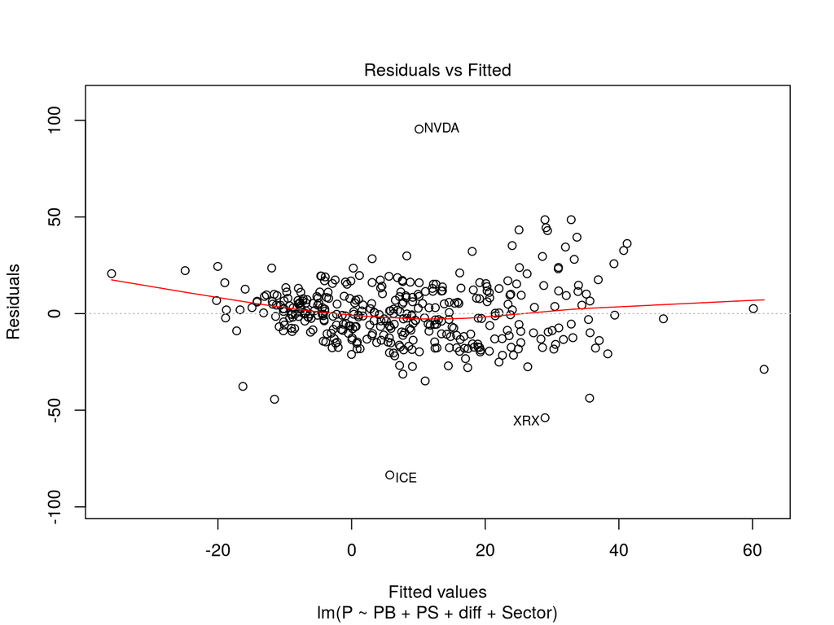

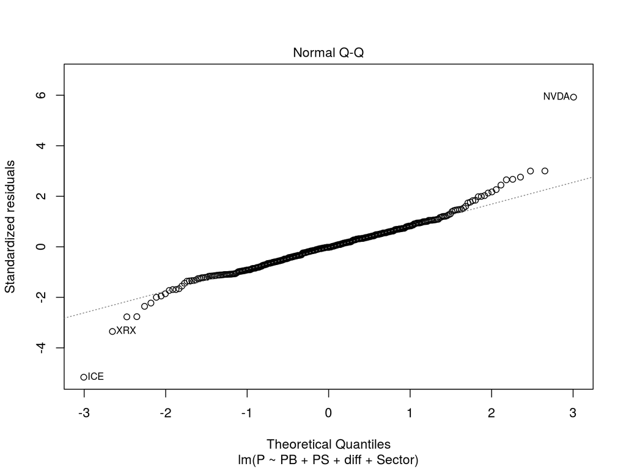

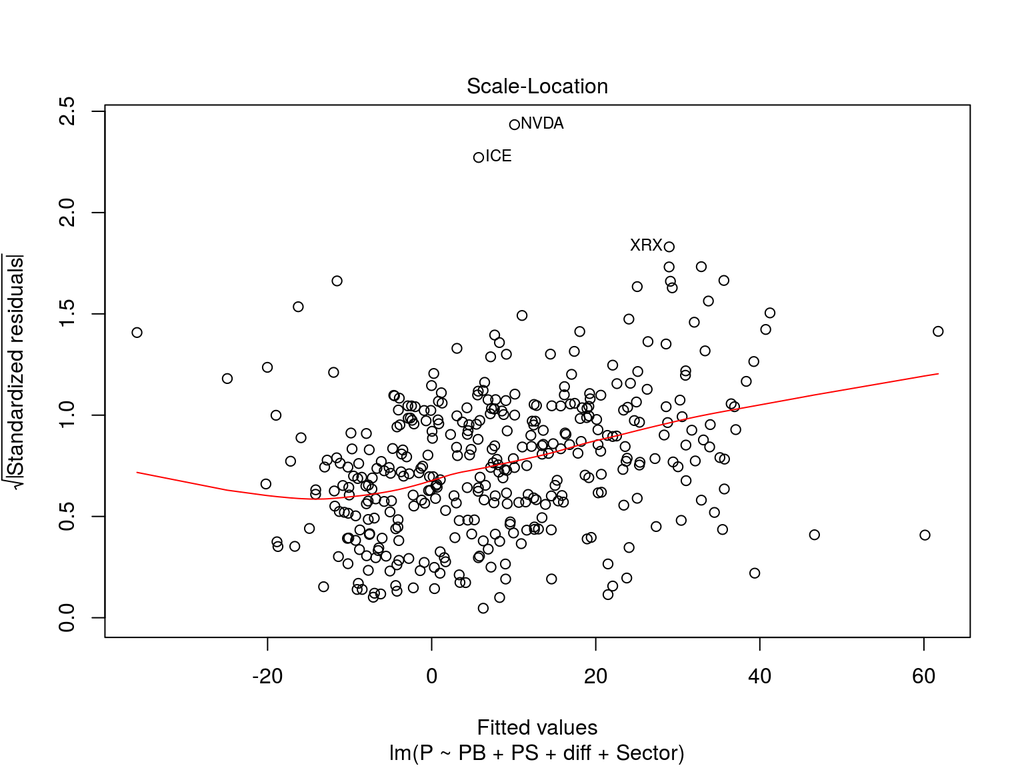

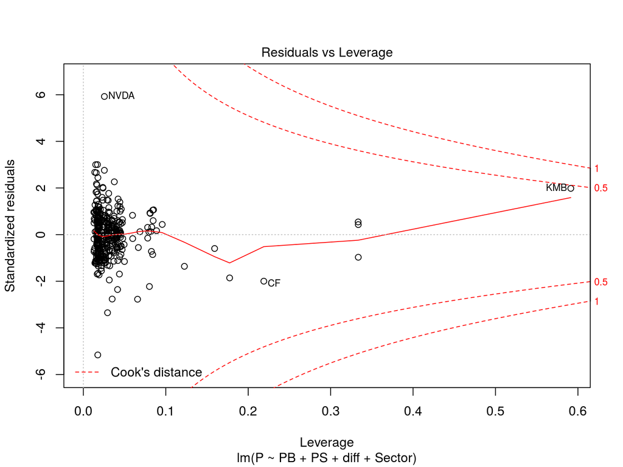

```r
plot(model,)
```

# Principal Component Analysis

We now look at the principal components in a standardized data set without the sector variable.

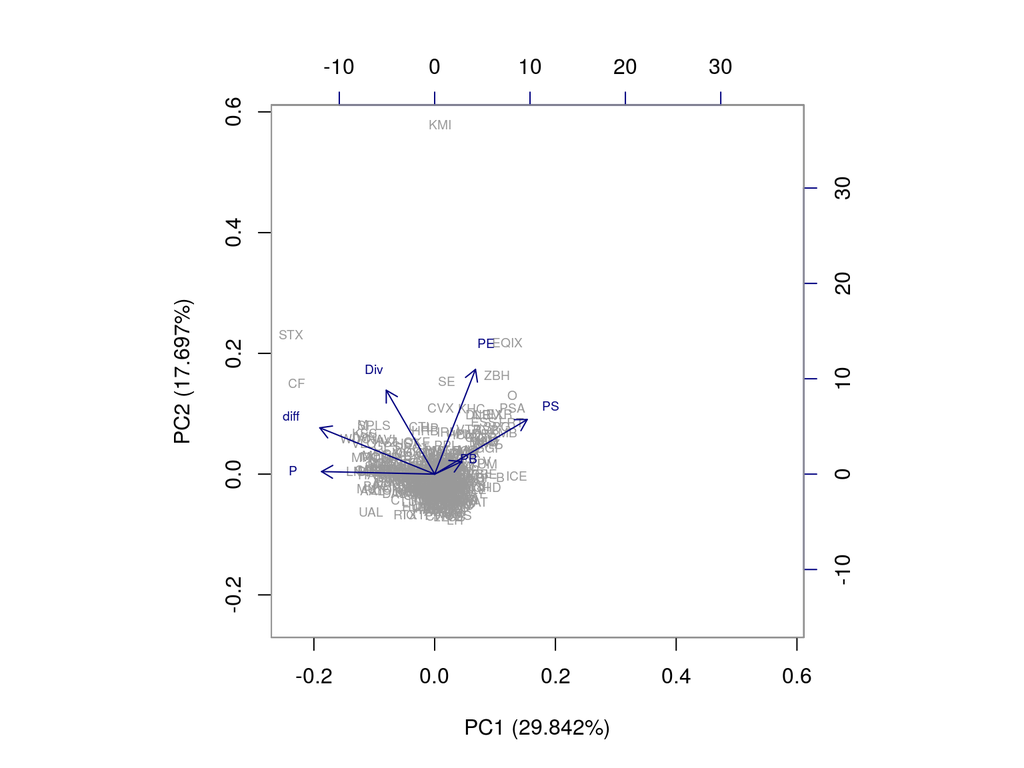

```r
fin_std <- scale(financial[,-1])

# print out summaries of the standardized variables
#summary(fin_std)

# perform principal component analysis (with the SVD method)
pca_fin <- prcomp(fin_std)

# rounded percetanges of variance captured by each PC
pca_percentages <- round(1*summary(pca_fin)$importance[2, ], digits = 5)*100

# print out the percentages of variance
#pca_percentages

# create object pc_lab to be used as axis labels
pca_labels <- paste0(names(pca_percentages), " (", pca_percentages, "%)")

# draw a biplot of the principal component representation and the original variables
biplot(pca_fin, choices = 1:2, cex = c(0.6, 0.6), col = c("grey60","navyblue"), xlab = pca_labels[1], ylab = pca_labels[2])
```

We can see that dividents are orthogonal to future price and PS-value. In terms of P, this is not surprising in a such short time period. Price to Earnings ratio is very weakly correlated with the rest of the variables, while price to sales is negatively correlated with future price and change from 52 week high (diff).

# Conclusions

We reject our null hypothesis that stock prices are not affected by current ratios on it’s pricing, that is, the SP500 stock market is not efficient from a theory perspective. Our analysis concentrated on the medium time interval of six months and this might change the results for a long run investor.